# Research 1-1: Highest Posterior Density Interval for a Binomial Parameter

Nahyun Lee

10/31/2024

## 1. Introduction

This research aims to calculate and visualize the Highest Posterior Density (HPD) credible interval for a binomial success probability parameter, denoted as $p$. We will use a Bayesian framework, which allows us to update our beliefs about a parameter after observing new data.

The core of this analysis is the Beta-Binomial conjugate model. Our initial belief about the parameter $p$ (the prior) is represented by a Beta distribution. After conducting a binomial experiment and observing a certain number of successes and failures, we update our belief to form a new distribution for $p$, known as the posterior distribution, which is also a Beta distribution.

For this specific analysis, we will: * Start with a `Beta(1,1)` prior, which is equivalent to a Uniform(0,1) distribution. This represents a state of no initial preference for any particular value of $p$. * Use data from an experiment with 1 success and 9 failures. * Calculate the 95% HPD credible interval for $p$ based on the resulting posterior distribution.

## 2. Methodology

### HPD Interval Calculation

The HPD credible interval is a special type of Bayesian credible interval. For a given probability (e.g., 95%), it is the **shortest possible interval** that contains the true parameter value with that probability. A key property is that the probability density of any point *inside* the interval is greater than or equal to the density of any point *outside* of it.

Our computational approach, implemented in the R function `calculate_hpd`, involves the following steps: 1. **Determine the Posterior Distribution**: Given a `Beta(shape1, shape2)` prior and observing `s` successes and `f` failures, the posterior distribution is `Beta(shape1 + s, shape2 + f)`. If the posterior is not unimodal (e.g., when it’s heavily skewed near 0 or 1), we approximate the mode using the mean-like formula:
$$\text{mode} \approx \frac{\alpha}{\alpha + \beta}$$
where $\alpha = \text{posterior\_shape1}, \beta = \text{posterior\_shape2}$ 2. **Find the Density Threshold ($t(\alpha)$)**: We numerically find a density value, $t$, such that the total area under the posterior curve where the density is *above* $t$ is exactly 95%. This is achieved using R’s `optimize` function. 3. **Identify Interval Endpoints**: The endpoints of the HPD interval are the values of $p$ where the posterior density is exactly equal to the threshold $t$. These points are found using a root-finding algorithm (`uniroot`).

### R Function Implementation

The following R code defines the `calculate_hpd` function which encapsulates the methodology described above.

```r
#' Function to calculate the HPD credible set
#'
#' @param successes Number of successes (x)
#' @param failures Number of failures (n-x)
#' @param shape1 First parameter of the prior Beta distribution
#' @param shape2 Second parameter of the prior Beta distribution
#' @param alpha Significance level (e.g., 0.05)
#' @return A list containing t_alpha (threshold), left_endpoint, right_endpoint

calculate_hpd <- function(successes, failures, shape1, shape2, alpha) {
  # Compute posterior distribution parameters
  posterior_shape1 <- shape1 + successes
  posterior_shape2 <- shape2 + failures

  # Check if the mode of the posterior distribution is between 0 and 1
  if (posterior_shape1 > 1 && posterior_shape2 > 1) {
    mode <- (posterior_shape1 - 1) / (posterior_shape1 + posterior_shape2 - 2)
  } else {
    # If the mode is near 0 or 1, adjust the starting point for search (mean-like fallback)
    mode <- posterior_shape1 / (posterior_shape1 + posterior_shape2)
  }

  # Define the posterior probability density function (pdf)
  posterior_pdf <- function(p) {
    dbeta(p, posterior_shape1, posterior_shape2)
  }

  # Find threshold t(alpha): the density level such that the area above it equals 1-alpha
  # Objective function: minimize (calculated probability - target probability)^2
  objective_function <- function(t) {
    # Define function f to solve dbeta(p) - t = 0
    f <- function(p) posterior_pdf(p) - t

    # Find roots to the left and right of the mode
    left_p <- uniroot(f, interval = c(1e-5, mode))$root
    right_p <- uniroot(f, interval = c(mode, 1 - 1e-5))$root

    # Compute probability between left_p and right_p
    prob <- pbeta(right_p, posterior_shape1, posterior_shape2) - pbeta(left_p, posterior_shape1, posterior_shape2)

    return((prob - (1 - alpha))^2)
  }

  # Find t_alpha via optimization
  max_density <- posterior_pdf(mode)
  opt_result <- optimize(objective_function, interval = c(1e-5, max_density))
  t_alpha <- opt_result$minimum

  # Find endpoints of the interval
  f_final <- function(p) posterior_pdf(p) - t_alpha

  # Left endpoint
  if (posterior_pdf(0) >= t_alpha) {
    left_endpoint <- 0
  } else {
    left_endpoint <- uniroot(f_final, interval = c(1e-5, mode))$root
  }

  # Right endpoint
  if (posterior_pdf(1) >= t_alpha) {
    right_endpoint <- 1
  } else {
    right_endpoint <- uniroot(f_final, interval = c(mode, 1 - 1e-5))$root
  }

  # Return results
  return(list(
    t_alpha = t_alpha,
    left_endpoint = left_endpoint,
    right_endpoint = right_endpoint
  ))
}
```

## 3. Results and Plot Analysis

Using the function defined above with our specified prior and data, we obtain the posterior distribution and its 95% HPD interval.

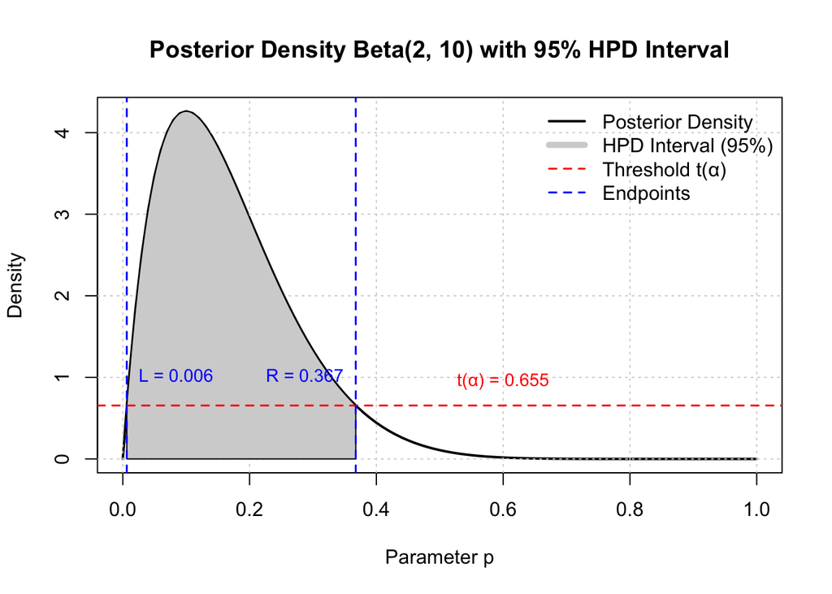

[output not shown]

```
## 95% HPD interval: [0.0063, 0.3675]
```

## 4. Conclusion

The visualization clearly illustrates the posterior distribution of $p$ and highlights the resulting credible interval, providing an intuitive and quantitatively robust summary of our uncertainty about the parameter after accounting for the data. This analysis serves as a practical example of the power of Bayesian inference.